# Predicting the price of Diamonds

#### Name(s) & ID(s) of Group Members: Radiyah Islam (s3866903) and Sayed Walif Ali (s3866910)

- Introduction
  - Dataset Source
  - Dataset Details
  - Dataset Features
  - Target Feature
- Goals and Objectives
- Data Cleaning and Preprocessing
- Data Exploration and Visualisation
- Literature Review
- Summary and Conclusion
- References

## Introduction

### Dataset Source

The "diamonds" dataset used in this study was sourced from the ggplot2 R library. This dataset contains information about the prices of diamonds.

### Dataset Details

The dataset is about the price of diamonds and contains information on diamonds including carat, clarity, cut, color and price. Additional features included in this dataset are length, width, depth, depth percentage and table percentage. These features seem to be sufficient for an attempt at predicting the prices of diamonds as a regression problem.

This dataset has a total of 10 features and 53940 observations.

### Dataset Features

The features in our dataset are described in the table below. These descriptions are taken from the ggplot R library source.

| Name | Data Type | Units | Description |
| --- | --- | --- | --- |
| carat | Numeric | Carat | Weight of the diamond |
| cut | Ordinal categorical | NA | Quality of the cut |
| color | Ordinal categorical | NA | Color of the diamond |
| clarity | Ordinal categorical | NA | Measurement of how clear the diamond is |
| depth | Numeric | NA | Total depth percentage |
| table | Numeric | NA | Percentage for width of top of diamond relative to widest point |
| x | Numeric | mm | Length of diamond |
| y | Numeric | mm | Width of diamond |
| z | Numeric | mm | Depth of diamond |
| price | Numeric | US $ | Price of diamond |

### Target Feature

For this project, the target feature in this dataset will be the price of diamonds in US dollars. That is, the price of diamonds will be predicted based on the descriptive variables.

## Goals and Objectives

A diamond is an incredibly popular stone that has its own separate industry. For this reason, a model that can accurately predict the price of a diamond would be extremely useful. For instance, jewelers can provide better service to their customers using this predictive model. Similarly, potential customers can use the model individually to figure out the ideal cut, clarity, and size of a diamond. They will be better equipped to understand whether they are being overcharged, provided that our predictive model produces a reliable estimate of the price.

Therefore, the main objective of this project is two-fold: 1) to predict the price of a diamond based on its features such as cut, clarity, etc. 2) which features have the highest impact on the price of a diamond. A secondary objective is to perform some exploratory data analytics by basic descriptive statistics and data visualisation plots to gain some insight into the patterns and relationships existing in the data subsequent to some data cleaning and preprocessing, which is the subject of this Phase 1 report.

At this point, we make the important assumption that the rows in our dataset are not correlated. That is, we assume that diamond price observations are independent of one another in this dataset. Of course, this is not a very realistic assumption, however, this assumption allows us to circumvent time series aspects of the underlying dynamics of diamond prices and also to resort to rather classical predictive models such as multiple linear regression. ("stats_tutorials/Sample_Phase1_Report.ipynb at master · vaksakalli/stats_tutorials", 2021)

## Data Cleaning and Preprocessing

In this section, we describe the data cleaning and preprocessing steps undertaken for this project.

### Data Retrieval

- We read in the dataset from ggplot2 R library and load the modules we will use throughout this report.
- We display 10 randomly sampled rows from this dataset.

```python
import warnings
warnings.filterwarnings("ignore")

import numpy as np
import pandas as pd
import io
import requests

pd.set_option('display.max_columns', None)

###
import matplotlib.pyplot as plt
import seaborn as sns
%matplotlib inline
%config InlineBackend.figure_format = 'retina'
plt.style.use("ggplot")
```

```python
#Reading in the 'diamonds' dataset
df = pd.read_csv('diamonds.csv')
```

```python
df.sample(10, random_state = 50)
```

|  | carat | cut | color | clarity | depth | table | x | y | z | price |
| --- | --- | --- | --- | --- | --- | --- | --- | --- | --- | --- |
| 44751 | 0.51 | Premium | F | VS2 | 61.4 | 58.0 | 5.13 | 5.09 | 3.14 | 1619 |
| 22963 | 2.01 | Ideal | J | SI2 | 62.9 | 54.0 | 8.06 | 7.93 | 5.05 | 11011 |
| 9078 | 1.08 | Ideal | I | SI1 | 62.1 | 59.0 | 6.57 | 6.53 | 4.07 | 4521 |
| 26148 | 2.13 | Very Good | G | SI2 | 61.5 | 57.0 | 8.27 | 8.34 | 5.11 | 15454 |
| 29451 | 0.33 | Ideal | E | SI1 | 61.9 | 56.0 | 4.46 | 4.49 | 2.77 | 702 |
| 23983 | 1.51 | Very Good | F | SI1 | 62.6 | 57.0 | 7.25 | 7.31 | 4.56 | 12141 |
| 24181 | 2.38 | Premium | J | SI1 | 62.4 | 58.0 | 8.54 | 8.46 | 5.31 | 12364 |
| 50466 | 0.72 | Ideal | I | VS1 | 62.3 | 55.0 | 5.79 | 5.69 | 3.58 | 2265 |
| 1844 | 0.70 | Very Good | E | VS1 | 62.2 | 57.0 | 5.63 | 5.68 | 3.52 | 3063 |
| 9443 | 1.00 | Ideal | D | SI1 | 63.0 | 56.0 | 6.33 | 6.28 | 3.97 | 4592 |

### Data Cleaning

- Drop irrelevant features in our dataset.
- Check and rename/ modify some column names.
- Check for missing values.
- Remove all the rows with missing values.
- Random sampling of the dataset for 5000 rows.

Let's first display all the columns in our dataset.

```python
df.columns
```

```
Index(['carat', 'cut', 'color', 'clarity', 'depth', 'table', 'x', 'y', 'z',
       'price'],
      dtype='object')
```

There are no irrelevant features in our dataset, so none of the columns have to be dropped.

Some of the columns are not labeled properly, which will be problematic when modeling. We will rename the columns for better readability. We will also remove any white spaces before & after column names.

```python
df.rename(columns={'x':'length'}, inplace=True)
df.rename(columns={'y':'width'}, inplace=True)
df.rename(columns={'depth':'depth_percentage'}, inplace=True)
df.rename(columns={'z':'depth'}, inplace=True)

df.sample(10, random_state = 50)
```

|  | carat | cut | color | clarity | depth_percentage | table | length | width | depth | price |
| --- | --- | --- | --- | --- | --- | --- | --- | --- | --- | --- |
| 44751 | 0.51 | Premium | F | VS2 | 61.4 | 58.0 | 5.13 | 5.09 | 3.14 | 1619 |
| 22963 | 2.01 | Ideal | J | SI2 | 62.9 | 54.0 | 8.06 | 7.93 | 5.05 | 11011 |
| 9078 | 1.08 | Ideal | I | SI1 | 62.1 | 59.0 | 6.57 | 6.53 | 4.07 | 4521 |
| 26148 | 2.13 | Very Good | G | SI2 | 61.5 | 57.0 | 8.27 | 8.34 | 5.11 | 15454 |
| 29451 | 0.33 | Ideal | E | SI1 | 61.9 | 56.0 | 4.46 | 4.49 | 2.77 | 702 |
| 23983 | 1.51 | Very Good | F | SI1 | 62.6 | 57.0 | 7.25 | 7.31 | 4.56 | 12141 |
| 24181 | 2.38 | Premium | J | SI1 | 62.4 | 58.0 | 8.54 | 8.46 | 5.31 | 12364 |
| 50466 | 0.72 | Ideal | I | VS1 | 62.3 | 55.0 | 5.79 | 5.69 | 3.58 | 2265 |
| 1844 | 0.70 | Very Good | E | VS1 | 62.2 | 57.0 | 5.63 | 5.68 | 3.52 | 3063 |
| 9443 | 1.00 | Ideal | D | SI1 | 63.0 | 56.0 | 6.33 | 6.28 | 3.97 | 4592 |

Next we check the data types.

```python
# Check for data types
print(f"Shape of the dataset = {df.shape} \n")
print(f"Data types are below where 'object' indicates a string type: ")
print(df.dtypes)
```

```
Shape of the dataset = (53940, 10)

Data types are below where 'object' indicates a string type:
carat               float64
cut                  object
color                object
clarity              object
depth_percentage    float64
table               float64
length              float64
width               float64
depth               float64
price                 int64
dtype: object
```

We have observed that the data types match the intended data types, thus no change is needed here.

The unique values for all columns with categorical data types are displayed to check for any white spaces and other data quality issues.

```python
from IPython.display import display, HTML
display(HTML('<b>Table 1: Summary of categorical features</b>'))
df.describe(include='object').T
```

**Table 1: Summary of categorical features**

|  | count | unique | top | freq |
| --- | --- | --- | --- | --- |
| cut | 53940 | 5 | Ideal | 21551 |
| color | 53940 | 7 | G | 11292 |
| clarity | 53940 | 8 | SI1 | 13065 |

```python
# To see all unique values for categorical data types
categoricalColumns = df.columns[df.dtypes==object].tolist()

for col in categoricalColumns:
    print('Unique values for ' + col)
    print(df[col].unique())
    print('')
```

```
Unique values for cut
['Ideal' 'Premium' 'Good' 'Very Good' 'Fair']

Unique values for color
['E' 'I' 'J' 'H' 'F' 'G' 'D']

Unique values for clarity
['SI2' 'SI1' 'VS1' 'VS2' 'VVS2' 'VVS1' 'I1' 'IF']
```

There are no absurd values or outliers in the data for categorical features. None of the values have unnecessary white spaces.

```python
from IPython.display import display, HTML
display(HTML('<b>Table 2: Summary of numerical features</b>'))
df.describe(include=['int64','float64']).T
```

**Table 2: Summary of numerical features**

|  | count | mean | std | min | 25% | 50% | 75% | max |
| --- | --- | --- | --- | --- | --- | --- | --- | --- |
| carat | 53940.0 | 0.797940 | 0.474011 | 0.2 | 0.40 | 0.70 | 1.04 | 5.01 |
| depth_percentage | 53940.0 | 61.749405 | 1.432621 | 43.0 | 61.00 | 61.80 | 62.50 | 79.00 |
| table | 53940.0 | 57.457184 | 2.234491 | 43.0 | 56.00 | 57.00 | 59.00 | 95.00 |
| length | 53940.0 | 5.731157 | 1.121761 | 0.0 | 4.71 | 5.70 | 6.54 | 10.74 |
| width | 53940.0 | 5.734526 | 1.142135 | 0.0 | 4.72 | 5.71 | 6.54 | 58.90 |
| depth | 53940.0 | 3.538734 | 0.705699 | 0.0 | 2.91 | 3.53 | 4.04 | 31.80 |
| price | 53940.0 | 3932.799722 | 3989.439738 | 326.0 | 950.00 | 2401.00 | 5324.25 | 18823.00 |

Based on the summary statistics table, there seems to be some outliers in the data. Length, width and depth have a minimum value of zero, which is impossible. So we will drop the rows that contain a 0 in these columns.

```python
zero_rows = df[(df['length']==0) | (df['width']==0) |(df['depth']==0)]
zero_rows.shape
```

```
(20, 10)
```

We can see that there are 20 rows that have outliers. First, we replace all the 0 values in these columns to 'NaN'.

```python
df[['length','width','depth']] = df[['length','width','depth']].replace(0,np.NaN)
```

Next, we check the missing values for all the columns.

```python
# Count missing values in each column
print(f"\nNumber of missing values for each column/ feature:")
print(df.isnull().sum())
```

```
Number of missing values for each column/ feature:
carat                0
cut                  0
color                0
clarity              0
depth_percentage     0
table                0
length               8
width                7
depth               20
price                0
dtype: int64
```

We observe that only the columns we altered have rows with missing values. We drop those rows.

```python
#Dropping rows that contain outliers
df.dropna(inplace=True)
df.isnull().sum()
```

```
carat               0
cut                 0
color               0
clarity             0
depth_percentage    0
table               0
length              0
width               0
depth               0
price               0
dtype: int64
```

We can observe that none of the variables have any missing values anymore.

```python
def outliers(var):

    q1 = df[var].quantile(.25)
    q2 = df[var].quantile(.5)
    q3 = df[var].quantile(.75)
    iqr = q3-q1
    upper = float(q3+(1.5*iqr))
    lower = float(q1-(1.5*iqr))

    count = 0
    for i in df[var]:
        if (i > upper or i < lower):
            count+=1
        else:
            pass
    return count

for col in df.select_dtypes(exclude='object').columns:

    count = outliers(col)
    if count == 0:
        print('No outliers')
    else:
        print(col,outliers(col))
```

```
carat 1883
depth_percentage 2543
table 604
length 24
width 22
depth 29
price 3532
```

The data can now be considered clean.

### Random Sampling

```python
df.shape
```

```
(53920, 10)
```

As the data has more than 5000 rows, random sampling is done to get only 5000 rows out of the remaining 53920 rows for ease of computation. At the end, we display 5 random rows from our cleaned data.

```python
df = df.sample(n=5000, random_state=999)
df.shape
df.sample(5, random_state=999)
```

|  | carat | cut | color | clarity | depth_percentage | table | length | width | depth | price |
| --- | --- | --- | --- | --- | --- | --- | --- | --- | --- | --- |
| 9043 | 0.31 | Very Good | E | VS1 | 61.2 | 61.0 | 4.29 | 4.37 | 2.65 | 587 |
| 52086 | 0.72 | Ideal | D | SI2 | 62.3 | 57.0 | 5.80 | 5.75 | 3.60 | 2457 |
| 8207 | 0.90 | Ideal | H | VS2 | 62.5 | 53.0 | 6.17 | 6.22 | 3.87 | 4369 |
| 6614 | 0.90 | Premium | H | VS2 | 61.3 | 59.0 | 6.24 | 6.19 | 3.81 | 4082 |
| 29363 | 0.31 | Premium | G | VS2 | 61.5 | 59.0 | 4.35 | 4.33 | 2.67 | 698 |

## Data Exploration and Visualisation

Our dataset is now considered to be clean and we are ready to start visualising and exploring each of the features.

### Univariate Visualisation

#### Bar Chart of Color

We calculate the frequency of each color to see which color is the most popular in diamonds in a descending order.

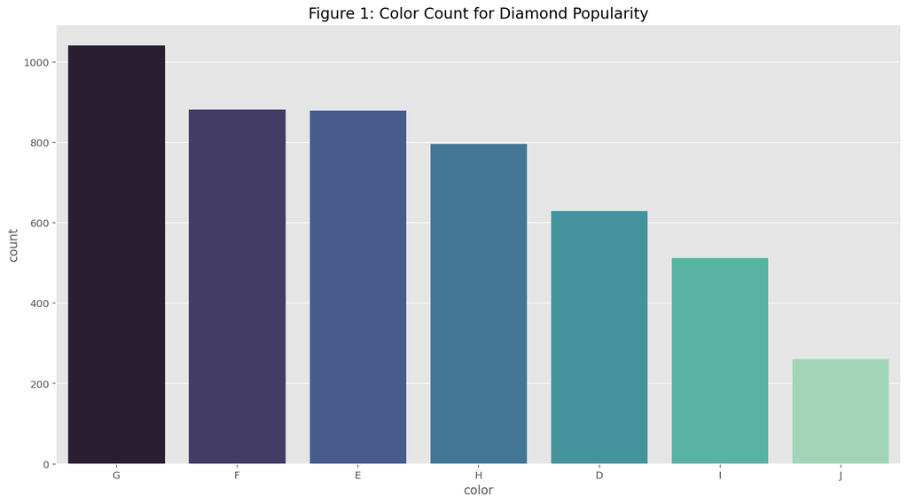

```python
plt.figure(figsize = (15,8))
fig = sns.countplot(x = 'color', data = df, palette = 'mako',
                    order = df['color'].value_counts().index)
fig = plt.title('Figure 1: Color Count for Diamond Popularity', fontsize = 15)
plt.show()
```

As we can see in Figure 1, the color `G` is the most popular in diamonds compared to diamonds of other colors. Diamonds having the color `J` have the lowest frequency in diamonds sold.

#### Boxplot of Carat

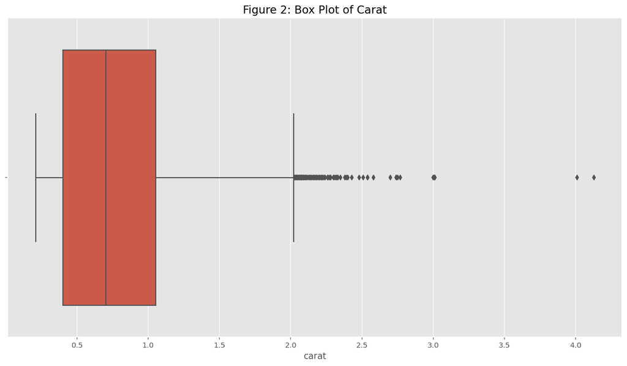

```python
# Boxplot of Carat
plt.figure(figsize = (15,8))
sns.boxplot(df['carat']).set_title('Figure 2: Box Plot of Carat', fontsize = 15)
plt.show();
```

As we can see in Figure 2, the distribution of carat is right-skewed, which means that diamonds with lower carats are sold more. The median weight of diamonds in carat is around 0.70.

#### Boxplot of Price

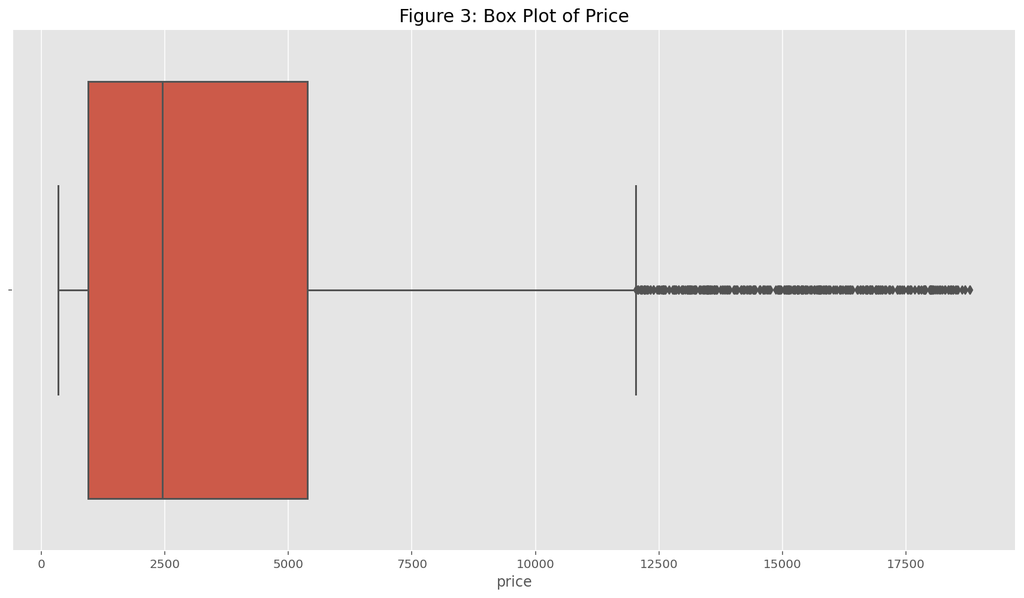

```python
# Boxplot of Price
plt.figure(figsize = (15,8))
sns.boxplot(df['price']).set_title('Figure 3: Box Plot of Price', fontsize = 15)
plt.show();
```

According to the boxplot in Figure 3, price is right-skewed and has a large range. This indicates that the price variable will need a log transformation in phase II of the project.